# Bankruptcy Predictive Analysis

Kalyani Nikure

04/05/2021

## Goal

The objective of Bankruptcy Predictive Analysis is the development of an assessment model that allows to predict financial condition of an organization by combining different financial ratios and attributes.

- Based on various financial ratios , predict whether the company got bankrupt in the subsequent years or not.
- Understanding the data and plotting relationship between them.

Note: This is an R Markdown document for our project. Markdown is a simple formatting syntax for authoring HTML, PDF, and MS Word documents. For more details on using R Markdown see http://rmarkdown.rstudio.com. When you click the **Knit** button a document will be generated that includes both content as well as the output of any embedded R code chunks within the document.

## Agenda

- Get the data
- Data Pre-processing
- Build a model
- Predictions
- Results

## About Data set Used

For this project, we used data collected from the Emerging Markets Information Service (EMIS), an information database about emerging markets worldwide. The dataset is about bankruptcy forecast of Polish companies. The bankrupt companies were analyzed in the period 2000-2012, while the still operating companies were evaluated from 2007 to 2013. Source: https://archive.ics.uci.edu/ml/datasets/Polish+companies+bankruptcy+data

The dataset consists of 43,400 Instances and 64 Attributes in CSV Format.

## Attribute Information

• Attr1 net profit / total assets

• Attr2 total liabilities / total assets

• Attr3 working capital / total assets

• Attr4 current assets / short-term liabilities

• Attr5 [(cash + short-term securities + receivables - short-term liabilities) / (operating expenses - depreciation)] * 365

• Attr6 retained earnings / total assets

• Attr7 EBIT / total assets

• Attr8 book value of equity / total liabilities

• Attr9 sales / total assets

• Attr10 equity / total assets

• Attr11 (gross profit + extraordinary items + financial expenses) / total assets

• Attr12 gross profit / short-term liabilities

• Attr13 (gross profit + depreciation) / sales

• Attr14 (gross profit + interest) / total assets

• Attr15 (total liabilities * 365) / (gross profit + depreciation)

• Attr16 (gross profit + depreciation) / total liabilities

• Attr17 total assets / total liabilities

• Attr18 gross profit / total assets

• Attr19 gross profit / sales

• Attr20 (inventory * 365) / sales

• Attr21 sales (n) / sales (n-1)

• Attr22 profit on operating activities / total assets

• Attr23 net profit / sales

• Attr24 gross profit (in 3 years) / total assets

• Attr25 (equity - share capital) / total assets

• Attr26 (net profit + depreciation) / total liabilities

• Attr27 profit on operating activities / financial expenses

• Attr28 working capital / fixed assets

• Attr29 logarithm of total assets

• Attr30 (total liabilities - cash) / sales

• Attr31 (gross profit + interest) / sales

• Attr32 (current liabilities * 365) / cost of products sold

• Attr33 operating expenses / short-term liabilities

• Attr34 operating expenses / total liabilities

• Attr35 profit on sales / total assets

• Attr36 total sales / total assets

• Attr37 (current assets - inventories) / long-term liabilities

• Attr38 constant capital / total assets

• Attr39 profit on sales / sales

• Attr40 (current assets - inventory - receivables) / short-term liabilities

• Attr41 total liabilities / ((profit on operating activities + depreciation) * (12/365))

• Attr42 profit on operating activities / sales

• Attr43 rotation receivables + inventory turnover in days

• Attr44 (receivables * 365) / sales

• Attr45 net profit / inventory

• Attr46 (current assets - inventory) / short-term liabilities

• Attr47 (inventory * 365) / cost of products sold

• Attr48 EBITDA (profit on operating activities - depreciation) / total assets

• Attr49 EBITDA (profit on operating activities - depreciation) / sales

• Attr50 current assets / total liabilities

• Attr51 short-term liabilities / total assets

• Attr52 (short-term liabilities * 365) / cost of products sold)

• Attr53 equity / fixed assets

• Attr54 constant capital / fixed assets

• Attr55 working capital

• Attr56 (sales - cost of products sold) / sales

• Attr57 (current assets - inventory - short-term liabilities) / (sales - gross profit - depreciation)

• Attr58 total costs /total sales

• Attr59 long-term liabilities / equity

• Attr60 sales / inventory

• Attr61 sales / receivables

• Attr62 (short-term liabilities *365) / sales

• Attr63 sales / short-term liabilities

• Attr64 sales / fixed assets

## Project Implementation using R Programming Language

### Import Libraries which are used

```r
library(ROSE)
```

```r
library(corrplot)
library(caret)
library(C50)
library(rpart)
library(rpart.plot)
library(DMwR2)
library(class)
library(mice)
library(vegan)
library(leaps)
library(inTrees)
library(e1071)
```

## Reading & Understanding the Data

### Read the Dataset

```r
setwd("C:/Users/nikur/OneDrive/Desktop/02 Introduction to Statistical Learning/R Programming")
dt <- read.csv("FinancialDataSet - Copy.csv")
```

### Understand the data

- Using the str(), summary(), head() and tail() functions to get the dimensions and types of attributes in the dataset
- The dataset has 43401 observations and 65 variables

```r
summary(dt)
```

```
##     Attr1              Attr2              Attr3              Attr4
##  Length:43401       Length:43401       Length:43401       Length:43401
##  Class :character   Class :character   Class :character   Class :character
##  Mode  :character   Mode  :character   Mode  :character   Mode  :character
##
##
##
##     Attr5              Attr6              Attr7              Attr8
##  Length:43401       Length:43401       Length:43401       Length:43401
##  Class :character   Class :character   Class :character   Class :character
##  Mode  :character   Mode  :character   Mode  :character   Mode  :character
##
##
##
##     Attr9              Attr10             Attr11             Attr12
##  Length:43401       Length:43401       Length:43401       Length:43401
##  Class :character   Class :character   Class :character   Class :character
##  Mode  :character   Mode  :character   Mode  :character   Mode  :character
##
##
##
##     Attr13             Attr14             Attr15             Attr16
##  Length:43401       Length:43401       Length:43401       Length:43401
##  Class :character   Class :character   Class :character   Class :character
##  Mode  :character   Mode  :character   Mode  :character   Mode  :character
##
##
##
##     Attr17             Attr18             Attr19             Attr20
##  Length:43401       Length:43401       Length:43401       Length:43401
##  Class :character   Class :character   Class :character   Class :character
##  Mode  :character   Mode  :character   Mode  :character   Mode  :character
##
##
##
##     Attr21             Attr22             Attr23             Attr24
##  Length:43401       Length:43401       Length:43401       Length:43401
##  Class :character   Class :character   Class :character   Class :character
##  Mode  :character   Mode  :character   Mode  :character   Mode  :character
##
```

[output cut: 64 more lines]

```
##
##     Attr61             Attr62             Attr63             Attr64
##  Length:43401       Length:43401       Length:43401       Length:43401
##  Class :character   Class :character   Class :character   Class :character
##  Mode  :character   Mode  :character   Mode  :character   Mode  :character
##
##
##
##      class
##  Min.   :0.00000
##  1st Qu.:0.00000
##  Median :0.00000
##  Mean   :0.04818
##  3rd Qu.:0.00000
##  Max.   :1.00000
```

```r
head(dt)
```

```
##      Attr1   Attr2   Attr3  Attr4   Attr5   Attr6    Attr7   Attr8  Attr9
## 1  0.20055 0.37951 0.39641 2.0472  32.351 0.38825  0.24976  1.3305 1.1389
## 2  0.20912 0.49988 0.47225 1.9447  14.786       0  0.25834 0.99601 1.6996
## 3  0.24866 0.69592 0.26713 1.5548 -1.1523       0  0.30906 0.43695  1.309
## 4 0.081483 0.30734 0.45879 2.4928  51.952 0.14988 0.092704  1.8661 1.0571
## 5  0.18732 0.61323  0.2296 1.4063 -7.3128 0.18732  0.18732  0.6307 1.1559
## 6  0.22822 0.49794 0.35969 1.7502 -47.717       0  0.28139  1.0083 1.9786
##    Attr10   Attr11  Attr12   Attr13   Attr14 Attr15  Attr16 Attr17   Attr18
## 1 0.50494  0.24976  0.6598   0.1666  0.24976 497.42 0.73378 2.6349  0.24976
## 2 0.49788  0.26114  0.5168  0.15835  0.25834 677.96 0.53838 2.0005  0.25834
## 3 0.30408  0.31258 0.64184  0.24435  0.30906 794.16 0.45961 1.4369  0.30906
## 4 0.57353 0.092704 0.30163 0.094257 0.092704 917.01 0.39803 3.2537 0.092704
## 5 0.38677  0.18732 0.33147  0.12182  0.18732 1133.2 0.32211 1.6307  0.18732
## 6 0.50206  0.28645 0.58691  0.14812  0.28139 620.14 0.58858 2.0083  0.28139
##     Attr19 Attr20 Attr21  Attr22   Attr23  Attr24  Attr25  Attr26  Attr27
```

[output cut: 34 more lines]

```r
tail(dt)
```

```
##          Attr1   Attr2     Attr3   Attr4   Attr5    Attr6    Attr7    Attr8
## 43396 -0.28338 0.97794  -0.12514 0.64902 -56.126  -1.3298 -0.28338 0.022514
## 43397 0.012898 0.70621  0.038857  1.1722 -18.907        0 0.013981    0.416
## 43398 -0.57805 0.96702  -0.80085 0.16576 -67.365 -0.57805 -0.57805 -0.40334
## 43399 -0.17905  1.2553  -0.27599 0.74554 -120.44 -0.17905 -0.15493 -0.26018
## 43400 -0.10886 0.74394  0.015449  1.0878 -17.003 -0.10886 -0.10918  0.12531
## 43401 -0.10537 0.53629 -0.045578 0.91478 -56.068 -0.10537 -0.10994   0.8646
##         Attr9   Attr10   Attr11   Attr12    Attr13   Attr14  Attr15    Attr16
## 43396  1.3943 0.022018 -0.28338 -0.79478  -0.20324 -0.28338 -1259.6  -0.28977
## 43397  1.6768  0.29379 0.041583 0.061959  0.023622 0.013981  6507.6  0.056089
## 43398 0.93979 -0.39004 -0.57805 -0.60216  -0.11022 -0.57805 -742.28  -0.49173
## 43399  1.1749 -0.32659 -0.15493 -0.14284  -0.07294 -0.15493 -3298.2  -0.11067
## 43400 0.84516 0.093224 -0.10918 -0.62038 -0.065652 -0.10918 -5352.1 -0.068197
## 43401  0.9504  0.46367 -0.10994 -0.20557 -0.066747 -0.10994 -2055.9  -0.17754
##        Attr17   Attr18    Attr19 Attr20  Attr21    Attr22    Attr23   Attr24
```

[output cut: 41 more lines]

```r
dim(dt)
```

```
## [1] 43401    65
```

### Verify Data Integrity to Verify the data types assigned to the variables in the dataset

```r
str(dt)
```

```
## 'data.frame':    43401 obs. of  65 variables:
##  $ Attr1 : chr  "0.20055" "0.20912" "0.24866" "0.081483" ...
##  $ Attr2 : chr  "0.37951" "0.49988" "0.69592" "0.30734" ...
##  $ Attr3 : chr  "0.39641" "0.47225" "0.26713" "0.45879" ...
##  $ Attr4 : chr  "2.0472" "1.9447" "1.5548" "2.4928" ...
##  $ Attr5 : chr  "32.351" "14.786" "-1.1523" "51.952" ...
##  $ Attr6 : chr  "0.38825" "0" "0" "0.14988" ...
##  $ Attr7 : chr  "0.24976" "0.25834" "0.30906" "0.092704" ...
##  $ Attr8 : chr  "1.3305" "0.99601" "0.43695" "1.8661" ...
##  $ Attr9 : chr  "1.1389" "1.6996" "1.309" "1.0571" ...
##  $ Attr10: chr  "0.50494" "0.49788" "0.30408" "0.57353" ...
##  $ Attr11: chr  "0.24976" "0.26114" "0.31258" "0.092704" ...
##  $ Attr12: chr  "0.6598" "0.5168" "0.64184" "0.30163" ...
##  $ Attr13: chr  "0.1666" "0.15835" "0.24435" "0.094257" ...
##  $ Attr14: chr  "0.24976" "0.25834" "0.30906" "0.092704" ...
```

[output cut: 51 more lines]

## Data pre-processing

### Converting columns to numeric values

```r
i <- c(1: 65)
dt[ , i] <- apply(dt[ , i], 2,            # Specify own function within apply
                    function(x) as.numeric(as.character(x)))
```

[output not shown]

[output cut: 72 more lines]

[output not shown]

```r
sum(is.na(dt))
```

```
## [1] 41322
```

```r
dt=centralImputation(dt)
sum(is.na(dt))
```

```
## [1] 0
```

### Check for class imbalance

```r
prop.table(table(dt$class))
```

```
##
##          0          1
## 0.95182139 0.04817861
```

```r
dt_rose <- ROSE(class~ ., data=dt, seed=111)$data
prop.table(table(dt_rose$class))
```

```
##
##         0         1
## 0.5009332 0.4990668
```

### Plot the important plots to understand data distribution

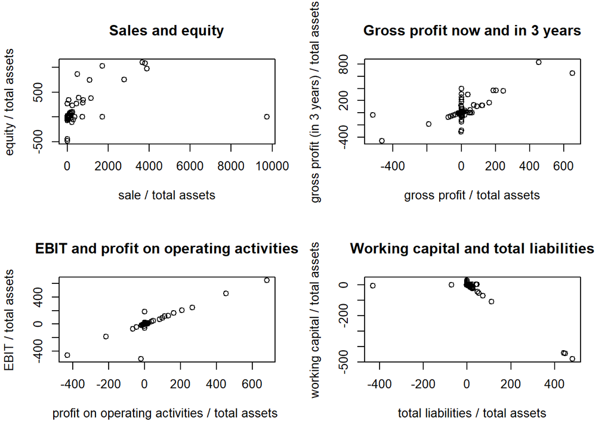

## Selection of important Features and Financial Ratios

### Find the corelation between the features

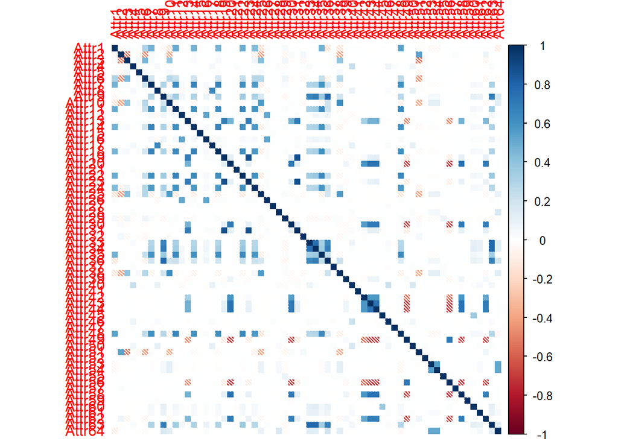

### Split the Data into train and test sets

- Use stratified sampling to split the data into train/test sets (70/30)
- Use the createDataPartition() function from the caret package to do stratified sampling

```r
# Set the seed after attaching the caret package
set.seed(111)
# The first argument is the imbalanced class reference variable, the second is the proportion to sample
# Remember to include list = F as the function returns a list otherwise which would not be able to subset a dataframe
trainIndex <- createDataPartition(dt$class, p = .7, list = F)
train_data <- dt[trainIndex, ]
test_data <- dt[-trainIndex, ]
```

## Best Subset Selection from all the attributes

### Perform regsubsets() to get the best subset

- Use best subset selection to find the best subset of features among all the attributes

```r
regfit.full = regsubsets(class~., data= train_data, really.big = T)
reg.summary = summary(regfit.full)
reg.summary
```

```
## Subset selection object
## Call: regsubsets.formula(class ~ ., data = train_data, really.big = T)
## 64 Variables  (and intercept)
##        Forced in Forced out
## Attr1      FALSE      FALSE
## Attr2      FALSE      FALSE
## Attr3      FALSE      FALSE
## Attr4      FALSE      FALSE
## Attr5      FALSE      FALSE
## Attr6      FALSE      FALSE
## Attr7      FALSE      FALSE
## Attr8      FALSE      FALSE
## Attr9      FALSE      FALSE
## Attr10     FALSE      FALSE
## Attr11     FALSE      FALSE
## Attr12     FALSE      FALSE
## Attr13     FALSE      FALSE
## Attr14     FALSE      FALSE
## Attr15     FALSE      FALSE
## Attr16     FALSE      FALSE
## Attr17     FALSE      FALSE
## Attr18     FALSE      FALSE
## Attr19     FALSE      FALSE
## Attr20     FALSE      FALSE
## Attr21     FALSE      FALSE
## Attr22     FALSE      FALSE
## Attr23     FALSE      FALSE
## Attr24     FALSE      FALSE
## Attr25     FALSE      FALSE
## Attr26     FALSE      FALSE
## Attr27     FALSE      FALSE
## Attr28     FALSE      FALSE
## Attr29     FALSE      FALSE
## Attr30     FALSE      FALSE
## Attr31     FALSE      FALSE
## Attr32     FALSE      FALSE
## Attr33     FALSE      FALSE
## Attr34     FALSE      FALSE
## Attr35     FALSE      FALSE
## Attr36     FALSE      FALSE
```

[output cut: 78 more lines]

```
## 3  ( 1 ) " "    " "    " "    " "    " "    " "    " "    " "    " "    " "
## 4  ( 1 ) " "    " "    " "    " "    " "    " "    " "    " "    " "    " "
## 5  ( 1 ) " "    " "    " "    " "    " "    " "    " "    " "    " "    " "
## 6  ( 1 ) " "    " "    " "    " "    " "    " "    " "    " "    " "    " "
## 7  ( 1 ) " "    " "    " "    " "    " "    " "    " "    " "    " "    " "
## 8  ( 1 ) " "    " "    " "    " "    " "    " "    " "    " "    " "    " "
##          Attr62 Attr63 Attr64
## 1  ( 1 ) " "    " "    " "
## 2  ( 1 ) " "    " "    " "
## 3  ( 1 ) " "    " "    " "
## 4  ( 1 ) " "    " "    " "
## 5  ( 1 ) " "    "*"    " "
## 6  ( 1 ) " "    "*"    " "
## 7  ( 1 ) " "    "*"    " "
## 8  ( 1 ) " "    "*"    " "
```

### Plot the best subset size

- Plot the best subset of features from the method

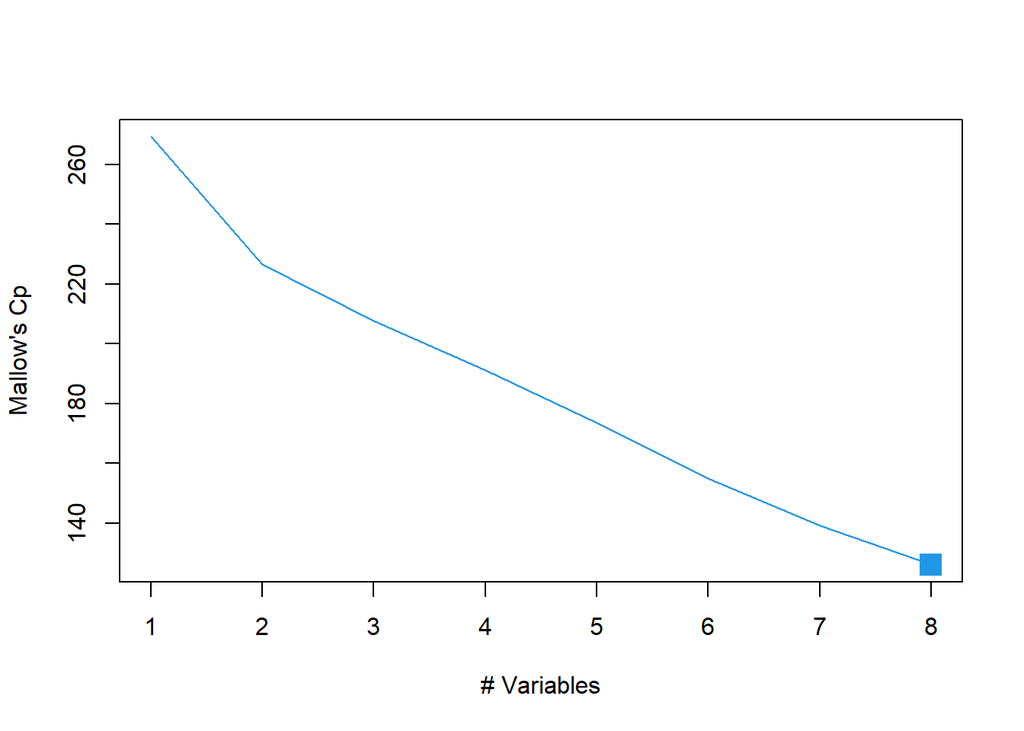

```
## [1] 8
```

## C5.0 Decision Tree

### Model the tree

- We will be using Quinlan’s C5.0 decision tree algorithm implementation from the C50 package to build our decision tree

```r
vars <- NULL
for(i in 1:64){
        vars <- cbind(vars, names(dt)[i])
}

c5_tree <- C5.0(x = train_data[, vars], y = as.factor(train_data$class))
# Use the rules = T argument if you want to extract rules later from the model
c5_rules <- C5.0(x = train_data[, vars], y = as.factor(train_data$class), rules = T)
```

### Variable Importance in trees

- Find the importance of each variable in the dataset using the c5imp() function
- The default metric “usage” in the c5imp function gives the percentage of data being split by using the attribute at that particular time. So variable used for splitting at the root node always has 100, and the variables at the leaf nodes might be close to 0 if there is no data remaining to classify

```r
C5imp(c5_tree, metric = "usage")
```

```
##        Overall
## Attr27  100.00
## Attr41  100.00
## Attr46   94.21
## Attr34   75.67
## Attr26   36.07
## Attr39   29.33
## Attr58   14.52
## Attr5    12.41
## Attr15    9.34
## Attr3     8.05
## Attr55    6.96
## Attr20    4.81
## Attr44    4.21
## Attr6     4.02
## Attr56    3.05
## Attr60    3.02
## Attr29    2.59
## Attr25    1.54
## Attr19    1.38
## Attr24    1.15
## Attr43    1.10
## Attr38    0.90
## Attr57    0.86
## Attr61    0.79
## Attr33    0.49
## Attr40    0.44
## Attr35    0.36
## Attr42    0.30
## Attr48    0.29
## Attr7     0.18
## Attr59    0.16
## Attr45    0.15
## Attr21    0.11
## Attr30    0.10
## Attr4     0.09
## Attr47    0.08
## Attr22    0.06
## Attr49    0.05
## Attr13    0.05
```

[output cut: 10 more lines]

```
## Attr14    0.00
## Attr16    0.00
## Attr17    0.00
## Attr18    0.00
## Attr23    0.00
## Attr31    0.00
## Attr32    0.00
## Attr36    0.00
## Attr50    0.00
## Attr52    0.00
## Attr53    0.00
## Attr54    0.00
## Attr62    0.00
## Attr63    0.00
## Attr64    0.00
```

### Rules from trees

- Understand the summary of the returned c5.0 rules based on the decision tree model

```r
summary(c5_rules)
```

```
##
## Call:
## C5.0.default(x = train_data[, vars], y = as.factor(train_data$class), rules = T)
##
##
## C5.0 [Release 2.07 GPL Edition]      Tue May 04 22:21:15 2021
## -------------------------------
##
## Class specified by attribute `outcome'
##
## Read 30381 cases (65 attributes) from undefined.data
##
## Rules:
##
## Rule 1: (1591/1, lift 1.0)
##  Attr27 <= -0.014747
##  Attr34 <= 0.010152
##  ->  class 0  [0.999]
##
## Rule 2: (2551/3, lift 1.0)
##  Attr5 > -795.79
##  Attr34 > 0.1515
##  Attr41 > -0.000156
##  Attr48 <= 0.0007001
##  Attr58 <= 0.90507
##  ->  class 0  [0.998]
##
## Rule 3: (434/6, lift 1.0)
##  Attr5 <= -676.43
##  Attr55 > -1103.4
##  Attr58 > 0.91294
##  ->  class 0  [0.984]
##
## Rule 4: (836/14, lift 1.0)
##  Attr4 > 0.7079
##  Attr5 <= -260.61
##  ->  class 0  [0.982]
##
## Rule 5: (2466/47, lift 1.0)
##  Attr5 > 180.77
```

[output cut: 249 more lines]

```
##    0.36% Attr20
##    0.17% Attr3
##    0.14% Attr39
##    0.14% Attr30
##    0.13% Attr19
##    0.12% Attr43
##    0.11% Attr33
##    0.11% Attr61
##    0.11% Attr40
##    0.08% Attr47
##    0.06% Attr38
##    0.02% Attr49
##
##
## Time: 4.1 secs
```

- From the output of the summary above, you can clearly understand the rules and their associated metrics such as lift and support
- **This is great for explicability and can also be used for understanding interesting relationships in data, even if your final model is not a decision tree**

### Plotting the tree

- Call the plot function on the tree object to visualize the tree

```r
plot(c5_tree)
```

[figure not shown]

## Evaluating the C5.0 Decision Tree model

### Predictions on the test data

- We’ll evaluate the decision tree using the standard error metrics on test data

```r
preds <- predict(c5_tree, train_data)
preds1 <- predict(c5_tree, test_data)
```

### Printing Confusion Matrix for Training and Testing Results

- Error metrics for classification can be accessed through the “confusionMatrix()” function from the caret package

```r
conf_train=confusionMatrix(preds, as.factor(train_data$class))
conf_test=confusionMatrix(preds1, as.factor(test_data$class))
# Confusion Matrix for Training dataset
conf_train
```

```
## Confusion Matrix and Statistics
##
##           Reference
## Prediction     0     1
##          0 28923   638
##          1    34   786
##
##                Accuracy : 0.9779
##                  95% CI : (0.9762, 0.9795)
##     No Information Rate : 0.9531
##     P-Value [Acc > NIR] : < 2.2e-16
##
##                   Kappa : 0.6899
##
##  Mcnemar's Test P-Value : < 2.2e-16
##
##             Sensitivity : 0.9988
##             Specificity : 0.5520
##          Pos Pred Value : 0.9784
##          Neg Pred Value : 0.9585
##              Prevalence : 0.9531
##          Detection Rate : 0.9520
##    Detection Prevalence : 0.9730
##       Balanced Accuracy : 0.7754
##
##        'Positive' Class : 0
##
```

```r
# Confusion Matrix for Testing dataset
conf_test
```

```
## Confusion Matrix and Statistics
##
##           Reference
## Prediction     0     1
##          0 12315   375
##          1    38   292
##
##                Accuracy : 0.9683
##                  95% CI : (0.9651, 0.9712)
##     No Information Rate : 0.9488
##     P-Value [Acc > NIR] : < 2.2e-16
##
##                   Kappa : 0.5712
##
##  Mcnemar's Test P-Value : < 2.2e-16
##
##             Sensitivity : 0.9969
##             Specificity : 0.4378
##          Pos Pred Value : 0.9704
##          Neg Pred Value : 0.8848
##              Prevalence : 0.9488
##          Detection Rate : 0.9459
##    Detection Prevalence : 0.9747
##       Balanced Accuracy : 0.7174
##
##        'Positive' Class : 0
##
```

## Finding the F1 score for C5.0 Decision tree

- F1 score is very important to have high precision and recall for this problem and Print F1 score.

```r
F1_score<-function(Recall, Precision)   {
     F1<-2*Recall*Precision/(Recall+Precision)
     return(F1)
}
recall_test <- sensitivity(preds1, as.factor(test_data$class))
precision_test <- posPredValue(preds1, as.factor(test_data$class))
F1_model_c5<-F1_score(recall_test, precision_test)
print(F1_model_c5)
```

```
## [1] 0.9835084
```

## CART Trees

- The Classification And Regression Trees (CART) use gini index in place of the gain ratio (based on information gain) used by the ID3 based algorithms, such as c4.5 and c5.0

### Goal

- The goal of this activity is to predict the bankruptcy of a company using a classification and regression tree (CART)

```r
reg_tree <- rpart(class ~ ., train_data, method='class')
printcp(reg_tree)
```

```
##
## Classification tree:
## rpart(formula = class ~ ., data = train_data, method = "class")
##
## Variables actually used in tree construction:
## [1] Attr24 Attr27 Attr34 Attr41 Attr44 Attr46 Attr5  Attr56
##
## Root node error: 1424/30381 = 0.046871
##
## n= 30381
##
##         CP nsplit rel error  xerror     xstd
## 1 0.028792      0   1.00000 1.00000 0.025871
## 2 0.015713      3   0.91362 0.91433 0.024790
## 3 0.013694     11   0.78792 0.82654 0.023621
## 4 0.010000     14   0.73666 0.76966 0.022825
```

### Tree Explicability

- The variable importance can accessed accessing variable.importance from the reg.tree list

```r
reg_tree$variable.importance
```

```
##     Attr34     Attr27     Attr58     Attr42     Attr33      Attr5     Attr55
## 259.964935 241.417166 141.670142 100.728392  95.304526  94.905254  89.968491
##     Attr41     Attr56     Attr30     Attr49     Attr29     Attr22     Attr16
##  81.874513  79.420090  74.712853  67.861045  65.413797  62.743146  50.268022
##     Attr26     Attr52     Attr32     Attr39      Attr4     Attr44     Attr62
##  49.417623  43.557374  41.275432  39.729956  38.815079  38.415943  38.083546
##     Attr61     Attr48      Attr9     Attr36     Attr40     Attr54     Attr53
##  37.729944  37.668854  37.619103  34.866486  32.347482  30.909816  29.472150
##     Attr46     Attr14     Attr11     Attr18     Attr12     Attr31     Attr24
##  27.536008  18.075792  14.695817  13.638990  13.465463  10.858701  10.288180
##      Attr3     Attr50     Attr28      Attr7     Attr15     Attr63      Attr1
##   9.599097   8.905862   8.434835   7.375345   6.810365   6.639403   3.391081
```

- We can plot the regression tree using the rpart.plot() function from the rpart.plot package

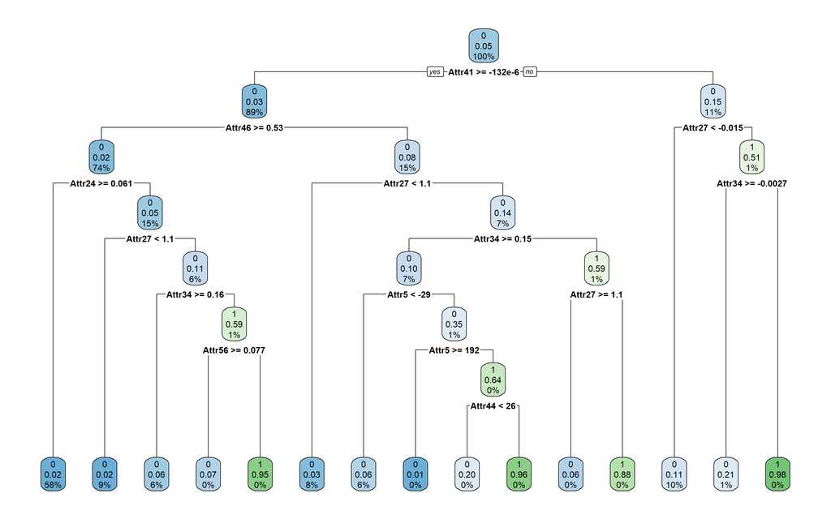

```r
rpart.plot(reg_tree)
```

## Evaluating the CART model

### Predictions on the test data

- We’ll evaluate the decision tree using the standard error metrics on test data

```r
summary(reg_tree) # detailed summary of splits
```

```
## Call:
## rpart(formula = class ~ ., data = train_data, method = "class")
##   n= 30381
##
##           CP nsplit rel error    xerror       xstd
## 1 0.02879213      0 1.0000000 1.0000000 0.02587145
## 2 0.01571278      3 0.9136236 0.9143258 0.02479044
## 3 0.01369382     11 0.7879213 0.8265449 0.02362101
## 4 0.01000000     14 0.7366573 0.7696629 0.02282532
##
## Variable importance
## Attr34 Attr27 Attr58 Attr42 Attr33  Attr5 Attr55 Attr41 Attr56 Attr30 Attr49
##     12     11      6      5      4      4      4      4      4      3      3
## Attr29 Attr22 Attr16 Attr26 Attr52 Attr32 Attr39  Attr4 Attr44 Attr62 Attr61
##      3      3      2      2      2      2      2      2      2      2      2
## Attr48  Attr9 Attr36 Attr40 Attr54 Attr53 Attr46 Attr14 Attr11 Attr18 Attr12
##      2      2      2      1      1      1      1      1      1      1      1
##
## Node number 1: 30381 observations,    complexity param=0.02879213
##   predicted class=0  expected loss=0.0468714  P(node) =1
##     class counts: 28957  1424
##    probabilities: 0.953 0.047
##   left son=2 (26915 obs) right son=3 (3466 obs)
##   Primary splits:
##       Attr41 < -0.000131595 to the right, improve=81.87451, (0 missing)
##       Attr35 < -0.0324685   to the right, improve=78.89337, (0 missing)
##       Attr39 < -0.0130985   to the right, improve=78.48167, (0 missing)
##       Attr26 < 0.0595185    to the right, improve=75.32862, (0 missing)
##       Attr46 < 0.396755     to the right, improve=74.31805, (0 missing)
##   Surrogate splits:
##       Attr22 < -0.042559    to the right, agree=0.972, adj=0.752, (0 split)
##       Attr42 < -0.0224045   to the right, agree=0.966, adj=0.703, (0 split)
##       Attr16 < -0.031785    to the right, agree=0.956, adj=0.614, (0 split)
##       Attr26 < -0.031031    to the right, agree=0.955, adj=0.604, (0 split)
##       Attr27 < -0.355225    to the right, agree=0.953, adj=0.586, (0 split)
##
## Node number 2: 26915 observations,    complexity param=0.01571278
##   predicted class=0  expected loss=0.03369868  P(node) =0.8859155
##     class counts: 26008   907
##    probabilities: 0.966 0.034
```

[output cut: 289 more lines]

```
##       Attr61 < 14.157       to the right, agree=0.993, adj=0.982, (0 split)
##       Attr33 < 7.27585      to the right, agree=0.874, adj=0.696, (0 split)
##       Attr52 < 0.137445     to the left,  agree=0.874, adj=0.696, (0 split)
##       Attr32 < 50.189       to the left,  agree=0.867, adj=0.679, (0 split)
##       Attr62 < 44.9075      to the left,  agree=0.867, adj=0.679, (0 split)
##
## Node number 182: 56 observations
##   predicted class=0  expected loss=0.1964286  P(node) =0.001843257
##     class counts:    45    11
##    probabilities: 0.804 0.196
##
## Node number 183: 79 observations
##   predicted class=1  expected loss=0.03797468  P(node) =0.002600309
##     class counts:     3    76
##    probabilities: 0.038 0.962
```

```r
pred2 = predict(reg_tree, train_data,type = "class")
pred3 = predict(reg_tree, test_data,type = "class")
table(pred2, train_data$class)
```

```
##
## pred2     0     1
##     0 28933  1025
##     1    24   399
```

```r
table(pred3, test_data$class)
```

```
##
## pred3     0     1
##     0 12339   507
##     1    14   160
```

### Printing Confusion Matrix for Training and Testing Results

- Error metrics for classification can be accessed through the “confusionMatrix()” function from the caret package

```r
conf_train=confusionMatrix(pred2, as.factor(train_data$class))
conf_test=confusionMatrix(pred3, as.factor(test_data$class))
# Confusion Matrix for Training dataset
conf_train
```

```
## Confusion Matrix and Statistics
##
##           Reference
## Prediction     0     1
##          0 28933  1025
##          1    24   399
##
##                Accuracy : 0.9655
##                  95% CI : (0.9634, 0.9675)
##     No Information Rate : 0.9531
##     P-Value [Acc > NIR] : < 2.2e-16
##
##                   Kappa : 0.4196
##
##  Mcnemar's Test P-Value : < 2.2e-16
##
##             Sensitivity : 0.9992
##             Specificity : 0.2802
##          Pos Pred Value : 0.9658
##          Neg Pred Value : 0.9433
##              Prevalence : 0.9531
##          Detection Rate : 0.9523
##    Detection Prevalence : 0.9861
##       Balanced Accuracy : 0.6397
##
##        'Positive' Class : 0
##
```

```r
# Confusion Matrix for Testing dataset
conf_test
```

```
## Confusion Matrix and Statistics
##
##           Reference
## Prediction     0     1
##          0 12339   507
##          1    14   160
##
##                Accuracy : 0.96
##                  95% CI : (0.9565, 0.9633)
##     No Information Rate : 0.9488
##     P-Value [Acc > NIR] : 1.002e-09
##
##                   Kappa : 0.3671
##
##  Mcnemar's Test P-Value : < 2.2e-16
##
##             Sensitivity : 0.9989
##             Specificity : 0.2399
##          Pos Pred Value : 0.9605
##          Neg Pred Value : 0.9195
##              Prevalence : 0.9488
##          Detection Rate : 0.9477
##    Detection Prevalence : 0.9866
##       Balanced Accuracy : 0.6194
##
##        'Positive' Class : 0
##
```

## Finding the F1 score for the CART tree

- F1 score is very important to have high precision and recall for this problem and Print F1 score.

```r
recall_test <- sensitivity(pred3, as.factor(test_data$class))
precision_test <- posPredValue(pred3, as.factor(test_data$class))
F1_model_rpart<-F1_score(recall_test,precision_test)
print(F1_model_rpart)
```

```
## [1] 0.9793246
```